# SAN chemicals

2025-12-14

```r
library(knitr)
library(haven)
library(dplyr)
library(car)
library(survey)
library(srvyr)
```

```r
library(ggplot2)
library(tidyr)
```

## Read datasets

```r
#Nacist data a z nekterych vybrat jen nektere promenne

#Demographics, RIDAGEYR - vek, RIDEXPRG - pregnant, DMDEDUC2 - education level, RIAGENDR - gender, INDFMPIR - ratio of family income to poverty
#RIDSTATR - both interview and MEC examination (2 - both, 1 - only interview)
demo_data = read_xpt("./data/DEMO_H.xpt") |> select(SEQN,RIDAGEYR,RIDEXPRG,DMDEDUC2,RIAGENDR,INDFMPIR,WTMEC2YR, SDMVPSU,SDMVSTRA)
#Reproductive health data, RHQ031 - had regular periods in past 12 months, RHQ074 - tried for a yer to become pregnant, RHQ076 - seen DR unable to become pregnant, RHQ131 - ever been pregnant,
#RHQ160 - how many times have been pregnant, RHQ171 - live birth deliveries, RHD280 - had a hysterectomy, RHQ078 - pelvic infection,RHD180 - age at firts livebirth
rhq_data = read_xpt("./data/RHQ_H.xpt") |> select(SEQN,RHQ031,RHQ074,RHQ076, RHQ131,RHQ160, RHQ171, RHD280, RHQ078, RHD180)
# SEx steroide hormone, LBXTST - testosterone (ng/dL), LBXEXT - estradiol(pg/mL), LBXSHGB (nmol/L), promene koncici na LC (0 - above detection limit, 1 below detection limit)
tst_data = read_xpt("./data/TST_H.xpt")
#Phtalates and plasticizesr metabolites
ssphte_data = read_xpt("./data/SSPHTE_H.xpt")

#Personal care and consumer product chemicals and metabolites
ephpp_data = read_xpt("./data/EPHPP_H.xpt")

#phtalates and plasticizers metabolites
phthte_data = read_xpt("./data/PHTHTE_H.xpt")

#alcohol use, ALQ120Q - How often drink alcohol over past 12 months
alq_data = read_xpt("./data/ALQ_H.xpt") |> select(SEQN,ALQ120Q)
#smoking cigarette use, SMQ040 - do you now smoke cigarettes, SMD650 avg cigarettes a day last month
smq_data = read_xpt("./data/SMQ_H.xpt") |> select(SEQN,SMQ040,SMD650)
#medical condition
#mcq_data = read_xpt("./data/MCQ_H.xpt") |> select(SEQN,)
#body measures, BMXBMI - body maxx index
bmx_data = read_xpt("./data/BMX_H.xpt") |> select(SEQN,BMXBMI)
```

## Merging datasets

```r
#iiner join keep only rows where there is a SEQN match in both datasets
merged_data = inner_join(demo_data, rhq_data, by = "SEQN")
merged_data = inner_join(merged_data, tst_data, by = "SEQN")
merged_data = inner_join(merged_data, ssphte_data, by = "SEQN")
merged_data = inner_join(merged_data, ephpp_data, by = "SEQN")
merged_data = inner_join(merged_data, alq_data, by = "SEQN")
merged_data = inner_join(merged_data, smq_data, by = "SEQN")
merged_data = inner_join(merged_data, bmx_data, by = "SEQN")
merged_data = inner_join(merged_data, phthte_data, by = "SEQN")
nrow(merged_data)
```

```
## [1] 917
```

```r
#jedna promena se vyskytuje ve vice datasetech
merged_data <- merged_data[, !grepl("\\.y$", names(merged_data))]
names(merged_data)[names(merged_data) == "URXUCR.x"] <- "URXUCR"
names(merged_data)[names(merged_data) == "WTSB2YR.x"] <- "WTSB2YR"

var_labels <- sapply(merged_data, function(x) attr(x, "label"))
labels_df <- data.frame(
  variable = names(var_labels),
  label = unname(var_labels)
)
print(labels_df)
```

```
##    variable                                    label
## 1      SEQN               Respondent sequence number
## 2  RIDAGEYR                Age in years at screening
## 3  RIDEXPRG                 Pregnancy status at exam
## 4  DMDEDUC2             Education level - Adults 20+
## 5  RIAGENDR                                   Gender
## 6  INDFMPIR        Ratio of family income to poverty
## 7  WTMEC2YR       Full sample 2 year MEC exam weight
## 8   SDMVPSU               Masked variance pseudo-PSU
## 9  SDMVSTRA           Masked variance pseudo-stratum
## 10   RHQ031    Had regular periods in past 12 months
## 11   RHQ074     Tried for a year to become pregnant?
## 12   RHQ076 Seen a DR b/c unable to become pregnant?
## 13   RHQ131                      Ever been pregnant?
## 14   RHQ160       How many times have been pregnant?
```

[output cut: 72 more lines]

## Remove, based on exclusion, inclusion criteria from the plan

```r
#age between 18 and 50 and female only, not pregnant
clean_data <- merged_data[merged_data$RIDAGEYR >= 18 & merged_data$RIDAGEYR <= 50 & merged_data$RIAGENDR == 2 & merged_data$RIDEXPRG == 2,]
nrow(clean_data)
```

```
## [1] 460
```

```r
#extreme urinary creatine values

clean_data <- clean_data[clean_data$URXUCR<300,]

#missing key covariates -> R si NaN values odstraní automaticky pri vytvareni modelu ?

#urinary chemicals measurement and MEC examination
clean_data <- clean_data[clean_data$WTSSBH2Y>0 & clean_data$WTSB2YR>0 & clean_data$WTMEC2YR>0,]
nrow(clean_data)
```

```
## [1] 448
```

```r
#at least one detectable urinary chemical measurement (ze vsech chemikalii v EPHPP a SSPHTE)
all_vars <- union(union(names(ssphte_data), names(ephpp_data)),names(phthte_data))
exclude_vars <- c( "SEQN","WTSSBH2Y","WTSB2YR" )
edc_vars <- setdiff(all_vars, exclude_vars)
length(edc_vars)
```

```
## [1] 55
```

```r
data_1 <- clean_data[
  rowSums(!is.na(clean_data[, edc_vars])) >= 1, #alespon jedna hodnota ze vsech merenych chemikalii neni Nan (missing)
]
# at least one detectable hormone measurement (not missing - nan)
horm_vars <- c("LBXSHBG","LBXEST","LBXTST")
data_1 <- data_1[
  rowSums(!is.na(data_1[, horm_vars])) >= 1, #alespon jedna hodnota ze vsech hormonu neni nan
]

nrow(data_1)
```

```
## [1] 324
```

## Survey design object -> to work with the weights

zdroj:https://wwwn.cdc.gov/nchs/nhanes/tutorials/weighting.aspx Weights are created in NHANES to account for the complex survey design (including oversamplig), survey non-response and post-stratification adjustment to match total population counts in the USA. A sample weight is assigned to each sample person. It is a measure of the number of people in the population represented by that sample person. NHANES: You must use the weight of the smallest subpopulation that includes all the variables you want to include in your analysis. Z tech mensich souboru obsahují speciální vahy jenom ty chemikálie (EPHPP a SSPHTE a PHTHTE). EPHPP a PHTHTE maji stejne (WTSB2YR) a SSPHTE ma jiné (WTSSBH2Y). Nevim ktera z nich by se mela pouzit, ale nejmensi je dataset SSPHTE. v ukazkach pak na vsechny upravy pouzivaji uz jenom survey desing objekt na práci s weighted NHANES dataset -> vytvorit z celych dat a znovu stejne profiltrovat

```r
data_w <- svydesign(id = ~SDMVPSU, strata= ~SDMVSTRA, weight=~WTSB2YR,   nest=TRUE, data=merged_data)

obj_cleaned <- data_w |>
  subset(
    RIDAGEYR >= 18 &
    RIDAGEYR <= 50 &
    RIAGENDR == 2 &
    RIDEXPRG == 2 &
    URXUCR < 300 &
    WTSSBH2Y > 0 &
    WTSB2YR > 0 &
    WTMEC2YR > 0 &
    rowSums(!is.na(as.data.frame(data_w$variables[, edc_vars]))) >= 1 &
    rowSums(!is.na(as.data.frame(data_w$variables[, horm_vars]))) >= 1
  )
nrow(obj_cleaned$variables)
```

```
## [1] 324
```

```r
summary(obj_cleaned)
```

```
## Stratified 1 - level Cluster Sampling design (with replacement)
## With (30) clusters.
## subset(data_w, RIDAGEYR >= 18 & RIDAGEYR <= 50 & RIAGENDR ==
##     2 & RIDEXPRG == 2 & URXUCR < 300 & WTSSBH2Y > 0 & WTSB2YR >
##     0 & WTMEC2YR > 0 & rowSums(!is.na(as.data.frame(data_w$variables[,
##     edc_vars]))) >= 1 & rowSums(!is.na(as.data.frame(data_w$variables[,
##     horm_vars]))) >= 1)
## Probabilities:
##      Min.   1st Qu.    Median      Mean   3rd Qu.      Max.
## 2.515e-06 6.348e-06 1.011e-05 1.047e-05 1.392e-05 3.033e-05
## Stratum Sizes:
##            104 105 106 107 108 109 110 111 112 113 114 115 116 117 118
## obs         13  18  20  26  20  21  15  26  29  22  27  23  20  17  27
## design.PSU   2   2   2   2   2   2   2   2   2   2   2   2   2   2   2
## actual.PSU   2   2   2   2   2   2   2   2   2   2   2   2   2   2   2
## Data variables:
##  [1] "SEQN"     "RIDAGEYR" "RIDEXPRG" "DMDEDUC2" "RIAGENDR" "INDFMPIR"
##  [7] "WTMEC2YR" "SDMVPSU"  "SDMVSTRA" "RHQ031"   "RHQ074"   "RHQ076"
## [13] "RHQ131"   "RHQ160"   "RHQ171"   "RHD280"   "RHQ078"   "RHD180"
## [19] "LBXTST"   "LBDTSTLC" "LBXEST"   "LBDESTLC" "LBXSHBG"  "LBDSHGLC"
## [25] "WTSSBH2Y" "URXUCR"   "SSURMHBP" "SDUMHBPL" "SSURHIBP" "SDUHIBPL"
## [31] "WTSB2YR"  "URXBP3"   "URDBP3LC" "URXBPH"   "URDBPHLC" "URXBPF"
## [37] "URDBPFLC" "URXBPS"   "URDBPSLC" "URXTLC"   "URDTLCLC" "URXTRS"
## [43] "URDTRSLC" "URXBUP"   "URDBUPLC" "URXEPB"   "URDEPBLC" "URXMPB"
## [49] "URDMPBLC" "URXPPB"   "URDPPBLC" "URX14D"   "URD14DLC" "URXDCB"
## [55] "URDDCBLC" "ALQ120Q"  "SMQ040"   "SMD650"   "BMXBMI"   "URXUCR"
## [61] "URXCNP"   "URDCNPLC" "URXCOP"   "URDCOPLC" "URXECP"   "URDECPLC"
## [67] "URXMBP"   "URDMBPLC" "URXMC1"   "URDMC1LC" "URXMEP"   "URDMEPLC"
## [73] "URXMHH"   "URDMHHLC" "URXMHNC"  "URDMCHLC" "URXMHP"   "URDMHPLC"
## [79] "URXMIB"   "URDMIBLC" "URXMNP"   "URDMNPLC" "URXMOH"   "URDMOHLC"
## [85] "URXMZP"   "URDMZPLC"
```

```r
#vytvoreny survey objekt porad obsahuje sloupce s vahama z vetsich datasetu -> pri vytvareni modelu upravit a nebrat je v uvahu
```

## Variables statistics

```r
#age
svymean(~RIDAGEYR,obj_cleaned,na.rm = TRUE)
```

```
##            mean     SE
## RIDAGEYR 32.326 0.7096
```

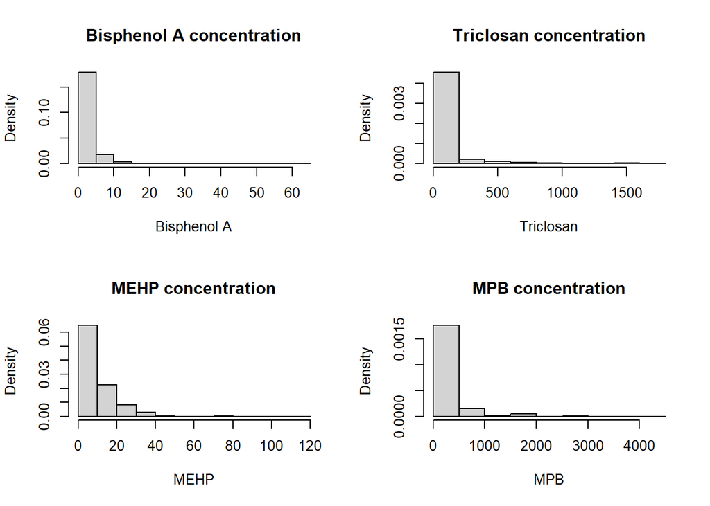

```r
 #visualize
par(mfrow = c(2, 2))
svyhist(~URXBPH, design=obj_cleaned, main="Bisphenol A concentration",xlab="Bisphenol A")
svyhist(~URXTRS, design=obj_cleaned, main="Triclosan concentration",xlab="Triclosan")
svyhist(~URXMHH, design=obj_cleaned, main="MEHP concentration",xlab="MEHP")
svyhist(~URXMPB, design=obj_cleaned, main="MPB concentration",xlab="MPB")
```

```r
par(mfrow = c(1, 1))
```

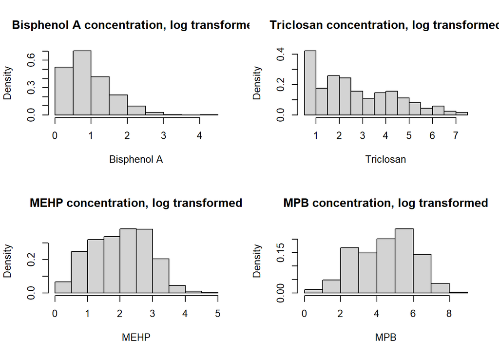

```r
par(mfrow = c(2, 2))
svyhist(~log(URXBPH + 1), design=obj_cleaned, main="Bisphenol A concentration, log transformed",xlab="Bisphenol A")
svyhist(~log(URXTRS + 1), design=obj_cleaned, main="Triclosan concentration, log transformed",xlab="Triclosan")
svyhist(~log(URXMHH + 1), design=obj_cleaned, main="MEHP concentration, log transformed",xlab="MEHP")
svyhist(~log(URXMPB + 1), design=obj_cleaned, main="MPB concentration, log transformed",xlab="MPB")
```

```r
par(mfrow = c(1, 1))
```

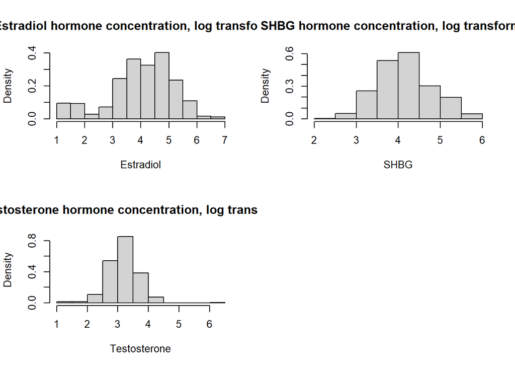

```r
par(mfrow = c(2, 2))
svyhist(~log(LBXEST + 1), design=obj_cleaned, main="Estradiol hormone concentration, log transformed",xlab="Estradiol")
svyhist(~log(LBXSHBG + 1), design=obj_cleaned, main="SHBG hormone concentration, log transformed",xlab="SHBG")
svyhist(~log(LBXTST + 1), design=obj_cleaned, main="Testosterone hormone concentration, log transformed",xlab="Testosterone")
par(mfrow = c(1, 1))
```

## PCA

V clanku (Association between co-exposure to phenols and phthalates mixture and infertility risk in women): Use PCA to deal with collinearity of chemicals -> get fewer independent components. Factors with eigen values higher than 1 were determined as the main components. Z 54 chemikalii se to zmensilo na 15 main components.

```r
#pridat dalsi sloupce do datasetu s logtransformovanymi chemikaliemi, edc_vars obsahuje jmena sloupcu vsech chemikalii v datasetu
obj_cleaned$variables[, paste0("log_", edc_vars)] <-log(obj_cleaned$variables[, edc_vars] + 1)
log_edc_vars <- paste0("log_", edc_vars) #log_edc_vars -> jmena vsech log transformovanych chemikalii

#pridat i log transformovane hormony do budoucna
obj_cleaned$variables$log_LBXEST <- log(obj_cleaned$variables$LBXEST + 1)
obj_cleaned$variables$log_LBXSHBG <- log(obj_cleaned$variables$LBXSHBG + 1)
obj_cleaned$variables$log_LBXTST <- log(obj_cleaned$variables$LBXTST + 1)

#potreba odstranit tuto chemikalii, jinak error: cannot rescale constant/zero column to unit variance, je to comment code (value 0 - at or above detection limit)
del <- c( "log_URDMEPLC" )
log_edc_vars <- setdiff(log_edc_vars,del)


pca_w <- svyprcomp(
  ~ as.matrix(obj_cleaned$variables[, log_edc_vars]),
  design = obj_cleaned,
  center = TRUE,
  scale  = TRUE
)

summary(pca_w)
```

```
## Importance of components:
##                           PC1     PC2     PC3     PC4     PC5    PC6    PC7
## Standard deviation     3.6704 2.21698 1.66427 1.60227 1.46470 1.3630 1.2835
## Proportion of Variance 0.2495 0.09102 0.05129 0.04754 0.03973 0.0344 0.0305
## Cumulative Proportion  0.2495 0.34050 0.39179 0.43933 0.47906 0.5135 0.5440
##                            PC8     PC9    PC10    PC11    PC12    PC13   PC14
## Standard deviation     1.22780 1.17369 1.16733 1.11589 1.09123 1.07147 1.0236
## Proportion of Variance 0.02792 0.02551 0.02523 0.02306 0.02205 0.02126 0.0194
## Cumulative Proportion  0.57189 0.59740 0.62263 0.64569 0.66774 0.68900 0.7084
##                           PC15    PC16    PC17    PC18    PC19    PC20    PC21
## Standard deviation     1.00989 0.97708 0.97394 0.95557 0.94227 0.88011 0.85459
## Proportion of Variance 0.01889 0.01768 0.01757 0.01691 0.01644 0.01434 0.01352
## Cumulative Proportion  0.72729 0.74497 0.76254 0.77945 0.79589 0.81023 0.82376
##                           PC22    PC23    PC24    PC25    PC26   PC27    PC28
## Standard deviation     0.79780 0.77014 0.74809 0.73141 0.72127 0.7048 0.68712
## Proportion of Variance 0.01179 0.01098 0.01036 0.00991 0.00963 0.0092 0.00874
## Cumulative Proportion  0.83555 0.84653 0.85689 0.86680 0.87643 0.8856 0.89438
##                           PC29    PC30    PC31    PC32    PC33    PC34   PC35
## Standard deviation     0.67646 0.66506 0.65618 0.60972 0.59421 0.58080 0.5691
## Proportion of Variance 0.00847 0.00819 0.00797 0.00688 0.00654 0.00625 0.0060
## Cumulative Proportion  0.90285 0.91104 0.91902 0.92590 0.93244 0.93868 0.9447
##                           PC36    PC37    PC38    PC39    PC40   PC41    PC42
## Standard deviation     0.55169 0.53131 0.52073 0.51261 0.50078 0.4761 0.46783
## Proportion of Variance 0.00564 0.00523 0.00502 0.00487 0.00464 0.0042 0.00405
## Cumulative Proportion  0.95032 0.95555 0.96057 0.96543 0.97008 0.9743 0.97833
##                           PC43    PC44    PC45    PC46    PC47    PC48    PC49
## Standard deviation     0.45673 0.41925 0.40815 0.36105 0.32378 0.30685 0.27925
## Proportion of Variance 0.00386 0.00326 0.00309 0.00241 0.00194 0.00174 0.00144
## Cumulative Proportion  0.98219 0.98545 0.98853 0.99095 0.99289 0.99463 0.99608
##                           PC50    PC51   PC52    PC53    PC54
## Standard deviation     0.27372 0.24625 0.1942 0.15436 0.12161
## Proportion of Variance 0.00139 0.00112 0.0007 0.00044 0.00027
## Cumulative Proportion  0.99746 0.99859 0.9993 0.99973 1.00000
```

```r
eigenvalues <- pca_w$sdev^2
prop_var    <- eigenvalues / sum(eigenvalues)
cum_var     <- cumsum(prop_var)

pca_table <- data.frame(
  PC = paste0("PC", seq_along(eigenvalues)),
  Eigenvalue = eigenvalues,
    Proportion_of_variance = prop_var,
  Cumulative_variance = cum_var
)

pca_table
```

```
##      PC  Eigenvalue Proportion_of_variance Cumulative_variance
## 1   PC1 13.47199921           0.2494814668           0.2494815
## 2   PC2  4.91501617           0.0910188180           0.3405003
## 3   PC3  2.76978822           0.0512923744           0.3917927
## 4   PC4  2.56726255           0.0475418991           0.4393346
## 5   PC5  2.14535004           0.0397287045           0.4790633
## 6   PC6  1.85783366           0.0344043270           0.5134676
## 7   PC7  1.64725265           0.0305046786           0.5439723
## 8   PC8  1.50748634           0.0279164138           0.5718887
## 9   PC9  1.37753841           0.0255099706           0.5973987
## 10 PC10  1.36265086           0.0252342752           0.6226329
## 11 PC11  1.24522132           0.0230596541           0.6456926
## 12 PC12  1.19078172           0.0220515133           0.6677441
## 13 PC13  1.14805364           0.0212602525           0.6890043
## 14 PC14  1.04770672           0.0194019763           0.7084063
```

[output cut: 40 more lines]

## Define fertility vs. infertility using only the reproductive questionnaire answer

For comparing chemical levels between case and control groups. Two questions from reproductive questionnaire were considered as the main indicators of fertility issues. 1 - YES, 2 - NO, Teoreticky v tom popisu na jejich webovkach nabizi i hodnotny pro I dont know a refused, ale z toho popisu co tma maji je nikdo nezvolil

```r
# Infertility issue variables : RHQ074  Tried for a year to become pregnant?, RHQ076    Seen a DR b/c unable to become pregnant?
#survey weighted correlation for binary variables -> Phi coefficient
x <- "RHQ074"
y <- "RHQ076"
f <- as.formula(paste("~", paste(c(x, y), collapse = " + ")))
vcov_mat <- svyvar(f, obj_cleaned, na.rm = TRUE)
sd_vec <- sqrt(diag(vcov_mat))
phi_w <- vcov_mat[1,2] / (sd_vec[1] * sd_vec[2])
phi_w
```

```
##    RHQ074
## 0.6701052
```

```r
#number of answers that are not nan
sum(!is.na(obj_cleaned$variables$RHQ074))
```

```
## [1] 286
```

```r
sum(!is.na(obj_cleaned$variables$RHQ076))
```

```
## [1] 286
```

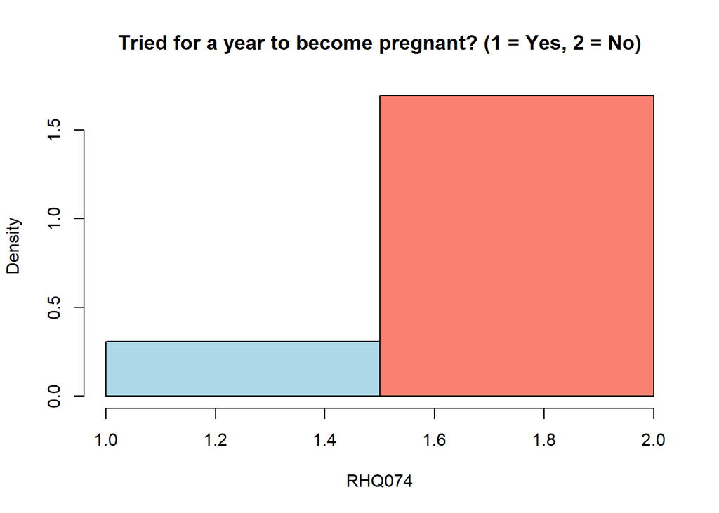

```r
svyhist(~RHQ074, design = obj_cleaned,breaks = 2,col = c("lightblue","salmon"),main = "Tried for a year to become pregnant? (1 = Yes, 2 = No)")
```

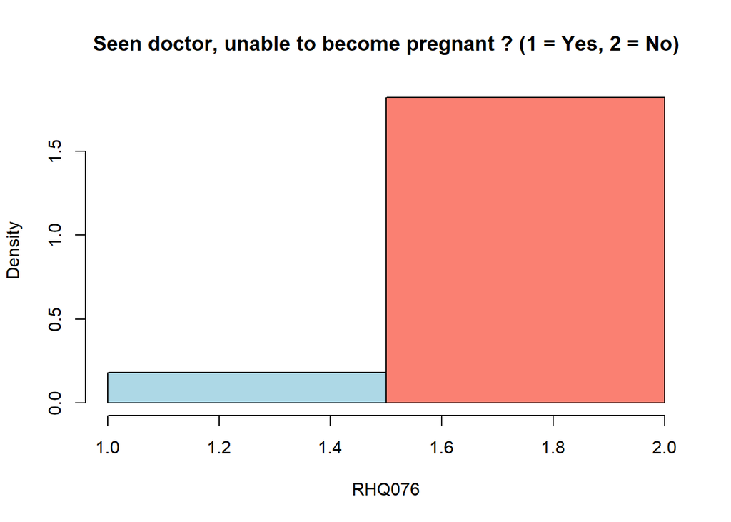

```r
svyhist(~RHQ076, design = obj_cleaned,breaks = 2,col = c("lightblue","salmon"),main = "Seen doctor, unable to become pregnant ? (1 = Yes, 2 = No)")
```

```r
#Kolik radku melo odpoved ano (Na to kolik to reprezentuje lidi by jsme asi museli pocitat s tema vahama)
sum(obj_cleaned$variables$RHQ074 == 1, na.rm = TRUE)
```

```
## [1] 37
```

## Chemical concentrations in case/control groups

Case group (infertile) lide kteri odpovedeli ano na Tried for 12 months to become pregnant. Control group (fertile) odpoved Ne The selection of chemicals presented in the boxplots below was based on previously published studies (references, ty co tam uz jsou v planu), which frequently focused on Bisphenol A, Triclosan, and MEHP among other compounds. The fourth phtalate choice was based on online resources.

z clanku (Screening for phthalates biomarkers and its potential role in infertility outcomes in Jordan) The graphs shows boxplots for four different compounds. The middle line represents the median while upper and lower box borders represent the first and third quartiles. The whiskers represent minimum and maximum value. The p-value below each graph is from Wilcoxon non parametric test. P-values less than 0.005 were considered significant. The test was performed using survey weighted Wilcoxon rank-sum test -> correct approach to account for NHANES complex sampling design.

```r
#URXBPH - bisphenol A
table(obj_cleaned$variables$RHQ074, useNA = "ifany")
```

```
##
##    1    2 <NA>
##   37  249   38
```

```r
summary(obj_cleaned$variables$log_URXBPH)
```

```
##    Min. 1st Qu.  Median    Mean 3rd Qu.    Max.
##  0.1310  0.5306  0.8542  0.9759  1.3350  4.1495
```

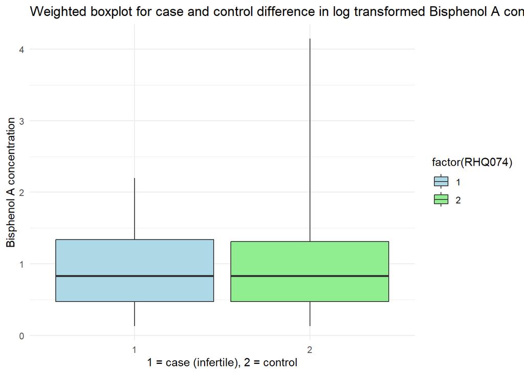

```r
subset_design <- subset(obj_cleaned, !is.na(RHQ074) & !is.na(log_URXBPH))

design_by_group <- svyby(
  ~log_URXBPH,
  ~RHQ074,
  subset_design,
  FUN = svyquantile,
  quantiles = c(0, 0.25, 0.5, 0.75, 1),
  na.rm = TRUE,
  ci = FALSE,       # Turn off confidence intervals first
  keep.var = FALSE
)
df_box <- design_by_group
names(df_box) <- c("RHQ074", "min", "Q1", "median", "Q3", "max")
df_box <- df_box %>% select(RHQ074, min, Q1, median, Q3, max)

ggplot(df_box, aes(x = factor(RHQ074), fill = factor(RHQ074))) +
  geom_boxplot(
    aes(
      ymin = min,
      lower = Q1,
      middle = median,
      upper = Q3,
      ymax = max
    ),
    stat = "identity"
  ) +
  scale_fill_manual(values = c("lightblue", "lightgreen")) +
  ylab("Bisphenol A concentration") +
  xlab("1 = case (infertile), 2 = control") +
  ggtitle("Weighted boxplot for case and control difference in log transformed Bisphenol A concentration") +
  theme_minimal()
```

```r
#Wilcoxon test
subset_design <- subset(
  obj_cleaned,
  !is.na(log_URXBPH) & !is.na(RHQ074)
)

wt <- svyranktest(
  log_URXBPH ~ factor(RHQ074),
  design = subset_design,
  test = "wilcoxon"
)
cat("Wilcoxon p-value:", signif(wt$p.value, 3), "\n")
```

```
## Wilcoxon p-value: 0.696
```

```r
#URXTRS - triclosan
table(obj_cleaned$variables$RHQ074, useNA = "ifany")
```

```
##
##    1    2 <NA>
##   37  249   38
```

```r
summary(obj_cleaned$variables$log_URXTRS)
```

```
##    Min. 1st Qu.  Median    Mean 3rd Qu.    Max.
##  0.7885  1.1862  2.1861  2.6402  3.7075  7.4152
```

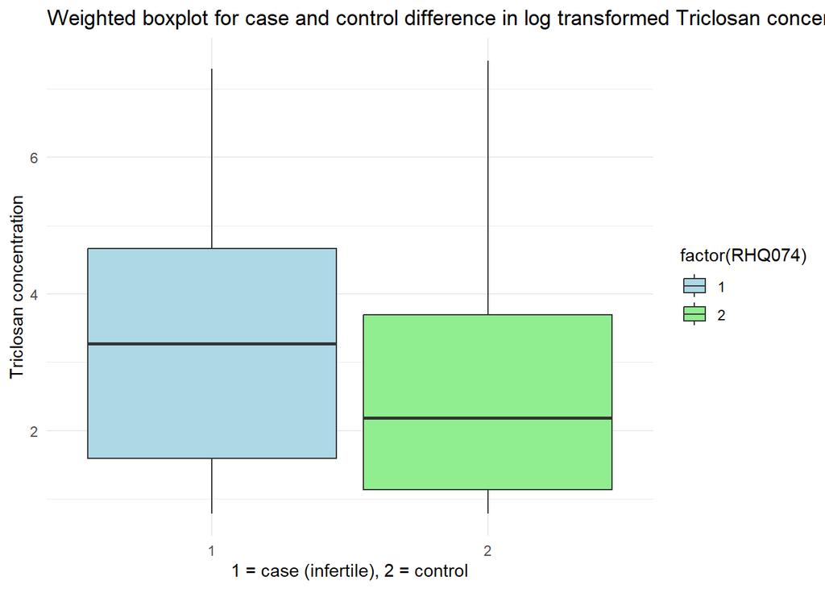

```r
subset_design <- subset(obj_cleaned, !is.na(RHQ074) & !is.na(log_URXTRS))

design_by_group <- svyby(
  ~log_URXTRS,
  ~RHQ074,
  subset_design,
  FUN = svyquantile,
  quantiles = c(0, 0.25, 0.5, 0.75, 1),
  na.rm = TRUE,
  ci = FALSE,       # Turn off confidence intervals first
  keep.var = FALSE
)
df_box <- design_by_group
names(df_box) <- c("RHQ074", "min", "Q1", "median", "Q3", "max")
df_box <- df_box %>% select(RHQ074, min, Q1, median, Q3, max)

ggplot(df_box, aes(x = factor(RHQ074), fill = factor(RHQ074))) +
  geom_boxplot(
    aes(
      ymin = min,
      lower = Q1,
      middle = median,
      upper = Q3,
      ymax = max
    ),
    stat = "identity"
  ) +
  scale_fill_manual(values = c("lightblue", "lightgreen")) +
  ylab("Triclosan concentration") +
  xlab("1 = case (infertile), 2 = control") +
  ggtitle("Weighted boxplot for case and control difference in log transformed Triclosan concentration") +
  theme_minimal()
```

```r
#Wilcoxon test
subset_design <- subset(
  obj_cleaned,
  !is.na(log_URXTRS) & !is.na(RHQ074)
)

wt <- svyranktest(
  log_URXTRS ~ factor(RHQ074),
  design = subset_design,
  test = "wilcoxon"
)
cat("Wilcoxon p-value:", signif(wt$p.value, 3), "\n")
```

```
## Wilcoxon p-value: 0.0364
```

```r
#URXMHH - MEHP
table(obj_cleaned$variables$RHQ074, useNA = "ifany")
```

```
##
##    1    2 <NA>
##   37  249   38
```

```r
summary(obj_cleaned$variables$log_URXMHH)
```

```
##    Min. 1st Qu.  Median    Mean 3rd Qu.    Max.
##  0.2469  1.3800  2.0669  2.0318  2.6479  4.7423
```

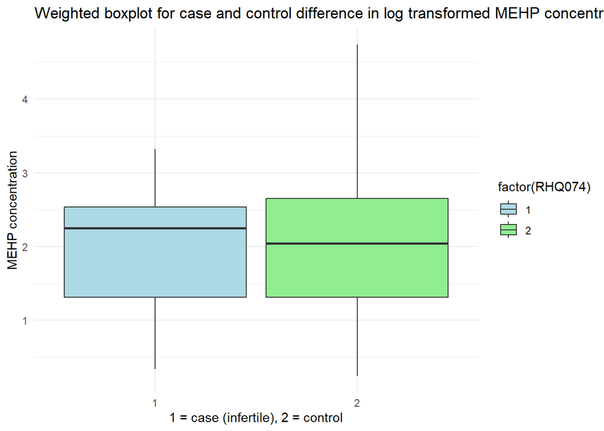

```r
subset_design <- subset(obj_cleaned, !is.na(RHQ074) & !is.na(log_URXMHH))

design_by_group <- svyby(
  ~log_URXMHH,
  ~RHQ074,
  subset_design,
  FUN = svyquantile,
  quantiles = c(0, 0.25, 0.5, 0.75, 1),
  na.rm = TRUE,
  ci = FALSE,       # Turn off confidence intervals first
  keep.var = FALSE
)
df_box <- design_by_group
names(df_box) <- c("RHQ074", "min", "Q1", "median", "Q3", "max")
df_box <- df_box %>% select(RHQ074, min, Q1, median, Q3, max)

ggplot(df_box, aes(x = factor(RHQ074), fill = factor(RHQ074))) +
  geom_boxplot(
    aes(
      ymin = min,
      lower = Q1,
      middle = median,
      upper = Q3,
      ymax = max
    ),
    stat = "identity"
  ) +
  scale_fill_manual(values = c("lightblue", "lightgreen")) +
  ylab("MEHP concentration") +
  xlab("1 = case (infertile), 2 = control") +
  ggtitle("Weighted boxplot for case and control difference in log transformed MEHP concentration") +
  theme_minimal()
```

```r
#Wilcoxon test
subset_design <- subset(
  obj_cleaned,
  !is.na(log_URXMHH) & !is.na(RHQ074)
)

wt <- svyranktest(
  log_URXMHH ~ factor(RHQ074),
  design = subset_design,
  test = "wilcoxon"
)
cat("Wilcoxon p-value:", signif(wt$p.value, 3), "\n")
```

```
## Wilcoxon p-value: 0.84
```

```r
#URXMPB - monobytyl phtalate
table(obj_cleaned$variables$RHQ074, useNA = "ifany")
```

```
##
##    1    2 <NA>
##   37  249   38
```

```r
summary(obj_cleaned$variables$log_URXMPB)
```

```
##    Min. 1st Qu.  Median    Mean 3rd Qu.    Max.
##  0.5365  3.3810  4.7829  4.5640  5.6931  8.3073
```

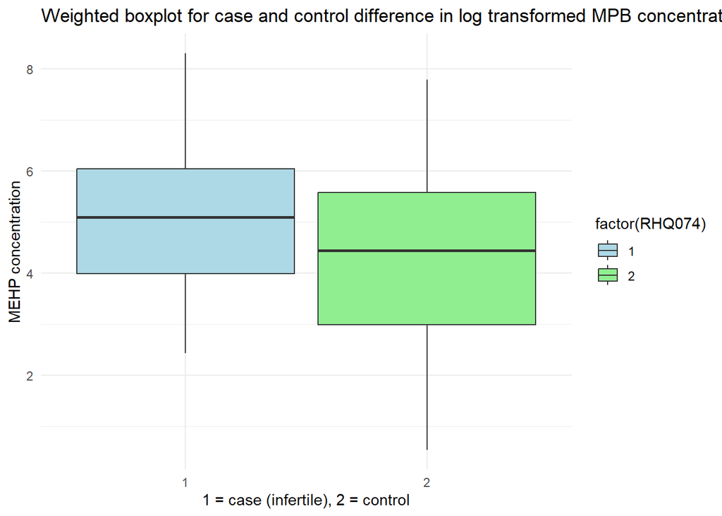

```r
subset_design <- subset(obj_cleaned, !is.na(RHQ074) & !is.na(log_URXMPB))

design_by_group <- svyby(
  ~log_URXMPB,
  ~RHQ074,
  subset_design,
  FUN = svyquantile,
  quantiles = c(0, 0.25, 0.5, 0.75, 1),
  na.rm = TRUE,
  ci = FALSE,       # Turn off confidence intervals first
  keep.var = FALSE
)
df_box <- design_by_group
names(df_box) <- c("RHQ074", "min", "Q1", "median", "Q3", "max")
df_box <- df_box %>% select(RHQ074, min, Q1, median, Q3, max)

ggplot(df_box, aes(x = factor(RHQ074), fill = factor(RHQ074))) +
  geom_boxplot(
    aes(
      ymin = min,
      lower = Q1,
      middle = median,
      upper = Q3,
      ymax = max
    ),
    stat = "identity"
  ) +
  scale_fill_manual(values = c("lightblue", "lightgreen")) +
  ylab("MEHP concentration") +
  xlab("1 = case (infertile), 2 = control") +
  ggtitle("Weighted boxplot for case and control difference in log transformed MPB concentration") +
  theme_minimal()
```

```r
#Wilcoxon test
subset_design <- subset(
  obj_cleaned,
  !is.na(log_URXMPB) & !is.na(RHQ074)
)

wt <- svyranktest(
  log_URXMPB ~ factor(RHQ074),
  design = subset_design,
  test = "wilcoxon"
)
cat("Wilcoxon p-value:", signif(wt$p.value, 3), "\n")
```

```
## Wilcoxon p-value: 0.0536
```

## Compare fertility vs. infertility with hormone levels

```r
table(obj_cleaned$variables$RHQ074, useNA = "ifany")
```

```
##
##    1    2 <NA>
##   37  249   38
```

```r
summary(obj_cleaned$variables$log_LBXEST)
```

```
##    Min. 1st Qu.  Median    Mean 3rd Qu.    Max.    NA's
##   1.137   3.597   4.274   4.133   4.852   6.639       5
```

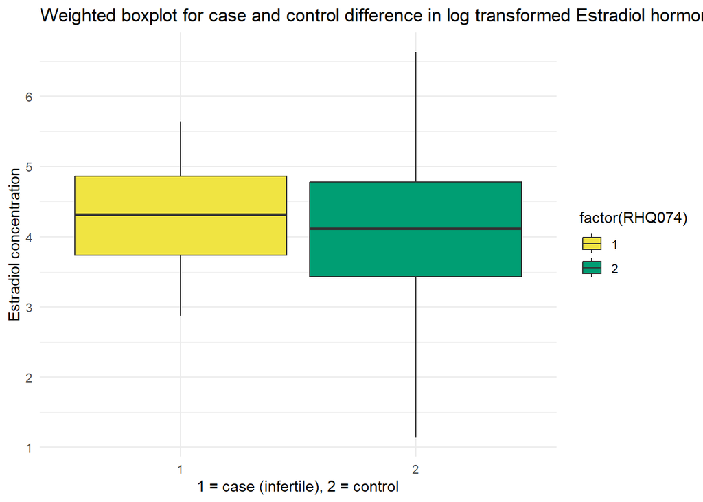

```r
subset_design <- subset(obj_cleaned, !is.na(RHQ074) & !is.na(log_LBXEST))

design_by_group <- svyby(
  ~log_LBXEST,
  ~RHQ074,
  subset_design,
  FUN = svyquantile,
  quantiles = c(0, 0.25, 0.5, 0.75, 1),
  na.rm = TRUE,
  ci = FALSE,       # Turn off confidence intervals first
  keep.var = FALSE
)
df_box <- design_by_group
names(df_box) <- c("RHQ074", "min", "Q1", "median", "Q3", "max")
df_box <- df_box %>% select(RHQ074, min, Q1, median, Q3, max)

ggplot(df_box, aes(x = factor(RHQ074), fill = factor(RHQ074))) +
  geom_boxplot(
    aes(
      ymin = min,
      lower = Q1,
      middle = median,
      upper = Q3,
      ymax = max
    ),
    stat = "identity"
  ) +
  scale_fill_manual(values = c("#F0E442", "#009E73")) +
  ylab("Estradiol concentration") +
  xlab("1 = case (infertile), 2 = control") +
  ggtitle("Weighted boxplot for case and control difference in log transformed Estradiol hormone concentration") +
  theme_minimal()
```

```r
#Wilcoxon test
subset_design <- subset(
  obj_cleaned,
  !is.na(log_LBXEST) & !is.na(RHQ074)
)

wt <- svyranktest(
  log_LBXEST ~ factor(RHQ074),
  design = subset_design,
  test = "wilcoxon"
)
cat("Wilcoxon p-value:", signif(wt$p.value, 3), "\n")
```

```
## Wilcoxon p-value: 0.27
```

```r
table(obj_cleaned$variables$RHQ074, useNA = "ifany")
```

```
##
##    1    2 <NA>
##   37  249   38
```

```r
summary(obj_cleaned$variables$log_LBXSHBG)
```

```
##    Min. 1st Qu.  Median    Mean 3rd Qu.    Max.    NA's
##   2.423   3.724   4.109   4.129   4.460   5.710      41
```

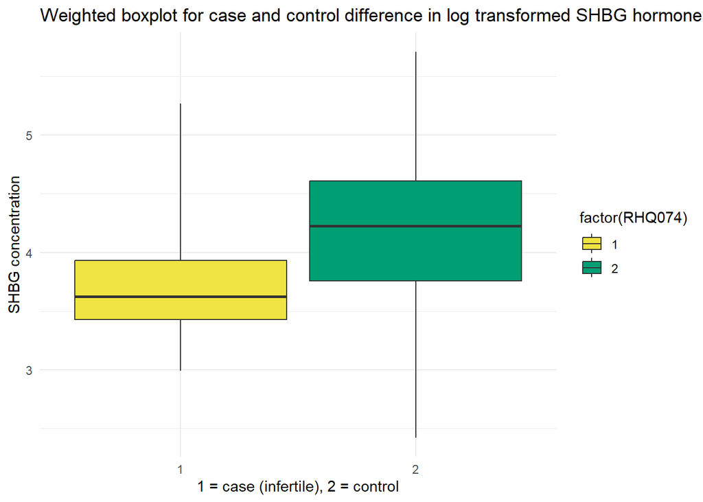

```r
subset_design <- subset(obj_cleaned, !is.na(RHQ074) & !is.na(log_LBXSHBG))

design_by_group <- svyby(
  ~log_LBXSHBG,
  ~RHQ074,
  subset_design,
  FUN = svyquantile,
  quantiles = c(0, 0.25, 0.5, 0.75, 1),
  na.rm = TRUE,
  ci = FALSE,       # Turn off confidence intervals first
  keep.var = FALSE
)
df_box <- design_by_group
names(df_box) <- c("RHQ074", "min", "Q1", "median", "Q3", "max")
df_box <- df_box %>% select(RHQ074, min, Q1, median, Q3, max)

ggplot(df_box, aes(x = factor(RHQ074), fill = factor(RHQ074))) +
  geom_boxplot(
    aes(
      ymin = min,
      lower = Q1,
      middle = median,
      upper = Q3,
      ymax = max
    ),
    stat = "identity"
  ) +
  scale_fill_manual(values = c("#F0E442", "#009E73")) +
  ylab("SHBG concentration") +
  xlab("1 = case (infertile), 2 = control") +
  ggtitle("Weighted boxplot for case and control difference in log transformed SHBG hormone concentration") +
  theme_minimal()
```

```r
#Wilcoxon test
subset_design <- subset(
  obj_cleaned,
  !is.na(log_LBXSHBG) & !is.na(RHQ074)
)

wt <- svyranktest(
  log_LBXSHBG ~ factor(RHQ074),
  design = subset_design,
  test = "wilcoxon"
)
cat("Wilcoxon p-value:", signif(wt$p.value, 3), "\n")
```

```
## Wilcoxon p-value: 0.0142
```

```r
table(obj_cleaned$variables$RHQ074, useNA = "ifany")
```

```
##
##    1    2 <NA>
##   37  249   38
```

```r
summary(obj_cleaned$variables$log_LBXTST)
```

```
##    Min. 1st Qu.  Median    Mean 3rd Qu.    Max.
##   1.376   2.861   3.178   3.173   3.464   6.356
```

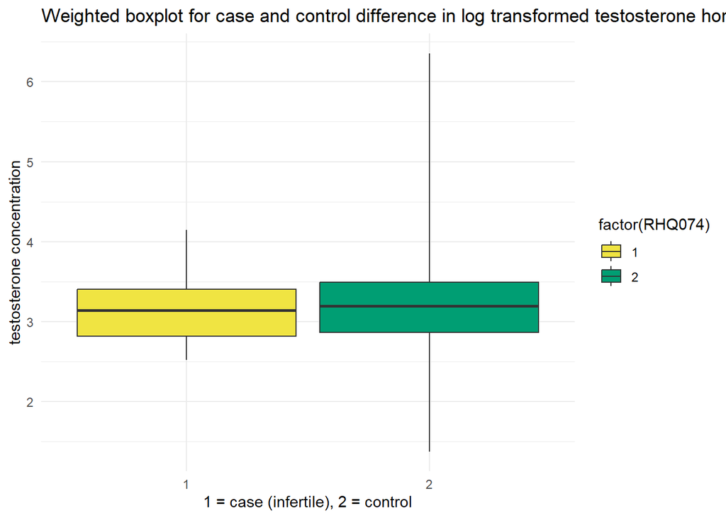

```r
subset_design <- subset(obj_cleaned, !is.na(RHQ074) & !is.na(log_LBXTST))

design_by_group <- svyby(
  ~log_LBXTST,
  ~RHQ074,
  subset_design,
  FUN = svyquantile,
  quantiles = c(0, 0.25, 0.5, 0.75, 1),
  na.rm = TRUE,
  ci = FALSE,       # Turn off confidence intervals first
  keep.var = FALSE
)
df_box <- design_by_group
names(df_box) <- c("RHQ074", "min", "Q1", "median", "Q3", "max")
df_box <- df_box %>% select(RHQ074, min, Q1, median, Q3, max)

ggplot(df_box, aes(x = factor(RHQ074), fill = factor(RHQ074))) +
  geom_boxplot(
    aes(
      ymin = min,
      lower = Q1,
      middle = median,
      upper = Q3,
      ymax = max
    ),
    stat = "identity"
  ) +
  scale_fill_manual(values = c("#F0E442", "#009E73")) +
  ylab("testosterone concentration") +
  xlab("1 = case (infertile), 2 = control") +
  ggtitle("Weighted boxplot for case and control difference in log transformed testosterone hormone concentration") +
  theme_minimal()
```

```r
#Wilcoxon test
subset_design <- subset(
  obj_cleaned,
  !is.na(log_LBXTST) & !is.na(RHQ074)
)

wt <- svyranktest(
  log_LBXTST ~ factor(RHQ074),
  design = subset_design,
  test = "wilcoxon"
)
cat("Wilcoxon p-value:", signif(wt$p.value, 3), "\n")
```

```
## Wilcoxon p-value: 0.348
```

```r
colnames(obj_cleaned)
```

```
##   [1] "SEQN"         "RIDAGEYR"     "RIDEXPRG"     "DMDEDUC2"     "RIAGENDR"
##   [6] "INDFMPIR"     "WTMEC2YR"     "SDMVPSU"      "SDMVSTRA"     "RHQ031"
##  [11] "RHQ074"       "RHQ076"       "RHQ131"       "RHQ160"       "RHQ171"
##  [16] "RHD280"       "RHQ078"       "RHD180"       "LBXTST"       "LBDTSTLC"
##  [21] "LBXEST"       "LBDESTLC"     "LBXSHBG"      "LBDSHGLC"     "WTSSBH2Y"
##  [26] "URXUCR"       "SSURMHBP"     "SDUMHBPL"     "SSURHIBP"     "SDUHIBPL"
##  [31] "WTSB2YR"      "URXBP3"       "URDBP3LC"     "URXBPH"       "URDBPHLC"
##  [36] "URXBPF"       "URDBPFLC"     "URXBPS"       "URDBPSLC"     "URXTLC"
##  [41] "URDTLCLC"     "URXTRS"       "URDTRSLC"     "URXBUP"       "URDBUPLC"
##  [46] "URXEPB"       "URDEPBLC"     "URXMPB"       "URDMPBLC"     "URXPPB"
##  [51] "URDPPBLC"     "URX14D"       "URD14DLC"     "URXDCB"       "URDDCBLC"
##  [56] "ALQ120Q"      "SMQ040"       "SMD650"       "BMXBMI"       "URXUCR.1"
##  [61] "URXCNP"       "URDCNPLC"     "URXCOP"       "URDCOPLC"     "URXECP"
##  [66] "URDECPLC"     "URXMBP"       "URDMBPLC"     "URXMC1"       "URDMC1LC"
##  [71] "URXMEP"       "URDMEPLC"     "URXMHH"       "URDMHHLC"     "URXMHNC"
##  [76] "URDMCHLC"     "URXMHP"       "URDMHPLC"     "URXMIB"       "URDMIBLC"
##  [81] "URXMNP"       "URDMNPLC"     "URXMOH"       "URDMOHLC"     "URXMZP"
##  [86] "URDMZPLC"     "log_URXUCR"   "log_SSURMHBP" "log_SDUMHBPL" "log_SSURHIBP"
##  [91] "log_SDUHIBPL" "log_URXBP3"   "log_URDBP3LC" "log_URXBPH"   "log_URDBPHLC"
##  [96] "log_URXBPF"   "log_URDBPFLC" "log_URXBPS"   "log_URDBPSLC" "log_URXTLC"
## [101] "log_URDTLCLC" "log_URXTRS"   "log_URDTRSLC" "log_URXBUP"   "log_URDBUPLC"
## [106] "log_URXEPB"   "log_URDEPBLC" "log_URXMPB"   "log_URDMPBLC" "log_URXPPB"
## [111] "log_URDPPBLC" "log_URX14D"   "log_URD14DLC" "log_URXDCB"   "log_URDDCBLC"
## [116] "log_URXCNP"   "log_URDCNPLC" "log_URXCOP"   "log_URDCOPLC" "log_URXECP"
## [121] "log_URDECPLC" "log_URXMBP"   "log_URDMBPLC" "log_URXMC1"   "log_URDMC1LC"
## [126] "log_URXMEP"   "log_URDMEPLC" "log_URXMHH"   "log_URDMHHLC" "log_URXMHNC"
## [131] "log_URDMCHLC" "log_URXMHP"   "log_URDMHPLC" "log_URXMIB"   "log_URDMIBLC"
## [136] "log_URXMNP"   "log_URDMNPLC" "log_URXMOH"   "log_URDMOHLC" "log_URXMZP"
## [141] "log_URDMZPLC" "log_LBXEST"   "log_LBXSHBG"  "log_LBXTST"
```